# Week5 Tutorial - Linear Regression

23/2/2021

```r
# Import libraries
library(tidyverse)
library(DataExplorer)
library(VIM)
library(mice)
library(missForest)
library(caret)
library(psych)
library(reshape2)
```

## 1. Dataset Description

### 1.1 General Information

#### Data Set: https://www.kaggle.com/codersree/mount-rainier-weather-and-climbing-data

#### Reference: https://www.kaggle.com/codersree/regression-models-to-predict-success-rate

1. As we all know, weather is a key factor in successful climbing. We try to investigate the relationship between success ratio and weather information.
2. The purpose of this project is to predict the success rate of climbing given historical climbing routes and the weather details of each day. The weather data is averaged on a daily basis.

### 1.2 Independent Variables

1. Date: date of which a data point is recorded.
2. Route (Categorical variable): several routes to climb Mt Rainier.
3. Attempted (Integer): total number of people who attempted to climb Mt Rainier.
4. Succeeded (Integer): total number of people who successfully climb Mt Rainier.
5. Battery.Voltage.AVG (Continuous variable): average value of voltage.
6. Temperature.AVG (Continuous variable): average value of temperature in Fahrenheit.
7. Relative.Humidity.AVG (Continuous variable): average value of humidity.
8. Wind.Speed.Daily.AVG (Continuous variable): average value of wind speed in MPH.
9. Wind.Direction.AVG (Continuous variable): average value of direction of the wind in DEG.
10. Solar.Radiation.AVG (Continuous variable): average value of solar radiation in Watts/square meter.

### 1.3 Dependent Variables

```r
# Load data
df.cs <- read.csv('climbing_statistics.csv', header = T)
df.rw <- read.csv('rainier_weather.csv', header = T)
```

## 2. Dataset Overview

```r
# View climbing statistics data
summary(df.cs)
```

```
     Date              Route             Attempted        Succeeded      Success.Percentage
 Length:4077        Length:4077        Min.   : 1.000   Min.   : 0.000   Min.   : 0.0000
 Class :character   Class :character   1st Qu.: 2.000   1st Qu.: 0.000   1st Qu.: 0.0000
 Mode  :character   Mode  :character   Median : 3.000   Median : 2.000   Median : 0.5833
                                       Mean   : 5.139   Mean   : 2.711   Mean   : 0.4990
                                       3rd Qu.: 8.000   3rd Qu.: 4.000   3rd Qu.: 1.0000
                                       Max.   :26.000   Max.   :71.000   Max.   :14.2000
```

```r
# View rainier weather data
summary(df.rw)
```

```
     Date           Battery.Voltage.AVG Temperature.AVG  Relative.Humidity.AVG
 Length:464         Min.   :12.83       Min.   :-0.166   Min.   :  9.66
 Class :character   1st Qu.:13.45       1st Qu.:19.074   1st Qu.: 38.16
 Mode  :character   Median :13.52       Median :27.355   Median : 64.10
                    Mean   :13.48       Mean   :28.023   Mean   : 62.55
                    3rd Qu.:13.61       3rd Qu.:36.115   3rd Qu.: 91.43
                    Max.   :13.86       Max.   :56.154   Max.   :100.00
 Wind.Speed.Daily.AVG Wind.Direction.AVG Solare.Radiation.AVG
 Min.   : 0.000       Min.   : 13.49     Min.   :  0.00
 1st Qu.: 2.918       1st Qu.:157.31     1st Qu.:  5.98
 Median : 8.708       Median :227.47     Median : 68.68
 Mean   :13.016       Mean   :199.44     Mean   :109.07
 3rd Qu.:18.727       3rd Qu.:257.73     3rd Qu.:196.04
 Max.   :65.853       Max.   :324.58     Max.   :368.06
```

## 3. Merge Datasets

Here, we combine these two data sets into one integrated data set. First, we need to check if these two data sets have missing values.

```r
sum(is.na(df.cs))
```

```
[1] 0
```

```r
sum(is.na(df.rw))
```

```
[1] 0
```

As we can see, these is no missing value in both data sets.

#### Merge two data sets into one integrated data set using left-merge operation by ‘date’ column.

```r
# Merge two data sets.
df = left_join(df.cs, df.rw, by=c("Date" = "Date"))
# New data set overview
summary(df)
```

```
     Date              Route             Attempted        Succeeded      Success.Percentage
 Length:4077        Length:4077        Min.   : 1.000   Min.   : 0.000   Min.   : 0.0000
 Class :character   Class :character   1st Qu.: 2.000   1st Qu.: 0.000   1st Qu.: 0.0000
 Mode  :character   Mode  :character   Median : 3.000   Median : 2.000   Median : 0.5833
                                       Mean   : 5.139   Mean   : 2.711   Mean   : 0.4990
                                       3rd Qu.: 8.000   3rd Qu.: 4.000   3rd Qu.: 1.0000
                                       Max.   :26.000   Max.   :71.000   Max.   :14.2000

 Battery.Voltage.AVG Temperature.AVG  Relative.Humidity.AVG Wind.Speed.Daily.AVG
 Min.   :12.99       Min.   : 6.835   Min.   : 12.36        Min.   : 0.000
 1st Qu.:13.45       1st Qu.:33.377   1st Qu.: 30.06        1st Qu.: 4.454
 Median :13.49       Median :40.049   Median : 46.14        Median : 7.396
 Mean   :13.50       Mean   :40.711   Mean   : 47.83        Mean   :10.504
 3rd Qu.:13.55       3rd Qu.:48.629   3rd Qu.: 64.75        3rd Qu.:14.658
 Max.   :13.79       Max.   :56.154   Max.   :100.00        Max.   :65.138
 NA's   :2182        NA's   :2182     NA's   :2182          NA's   :2182
 Wind.Direction.AVG Solare.Radiation.AVG
 Min.   : 13.49     Min.   :  0.0
 1st Qu.: 55.17     1st Qu.:221.5
 Median :171.63     Median :304.6
 Mean   :155.34     Mean   :261.6
 3rd Qu.:235.50     3rd Qu.:352.0
 Max.   :280.38     Max.   :368.1
 NA's   :2182       NA's   :2182
```

```r
# Dataset info
str(df)
```

```
'data.frame':   4077 obs. of  11 variables:
 $ Date                 : chr  "11/27/2015" "11/21/2015" "10/15/2015" "10/13/2015" ...
 $ Route                : chr  "Disappointment Cleaver" "Disappointment Cleaver" "Disappointment Cleaver" "Little Tahoma" ...
 $ Attempted            : int  2 3 2 8 2 10 2 2 2 2 ...
 $ Succeeded            : int  0 0 0 0 0 0 0 0 0 0 ...
 $ Success.Percentage   : num  0 0 0 0 0 0 0 0 0 0 ...
 $ Battery.Voltage.AVG  : num  13.6 13.7 13.5 13.5 13.2 ...
 $ Temperature.AVG      : num  26.3 31.3 46.4 41 38.3 ...
 $ Relative.Humidity.AVG: num  19.7 21.7 27.2 28.3 74.3 ...
 $ Wind.Speed.Daily.AVG : num  27.84 2.25 17.16 19.59 65.14 ...
 $ Wind.Direction.AVG   : num  68 118 259 280 265 ...
 $ Solare.Radiation.AVG : num  88.5 93.7 138.4 176.4 27.8 ...
```

## 4. Data Imputation

```r
# Prior to treating missing values any blanks in the data set must be converted to NA.
df <- mutate_all(df, na_if, "")
```

### 4.1 Drop Missing Values

The climbing statistics data set has 4077 records and the rainier weather data set has 464 records. After left joining together, there are some rows missing weather data. To me, it doesn’t make sense to impute missing weather values with the average or mean value of the month. Therefore, I would only use the climbing statistics where the weather values are available for those days.

```r
# Drop missing values.
df = na.omit(df)
```

### 4.2 Fix Outliers

In this data set, several succeeded ratio have values larger than 1.0, which is impossible. Therefore, we need to remove rows that contain this outliers.

```r
# Remove rows that contain succeeded ratio larger than 1.0.
df = df[which(df$Success.Percentage <= 1.0), ]
```

### 4.3 Plot Missing Values

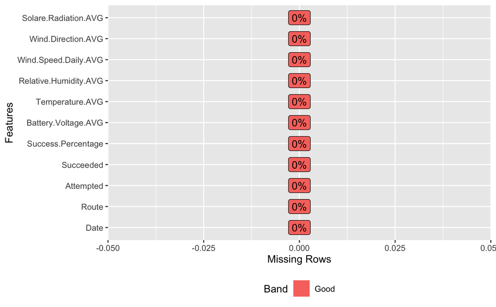

```r
# Viewing and counting missing data using DataExplorer package.
plot_missing(df)
```

Good News, there is no missing value now.

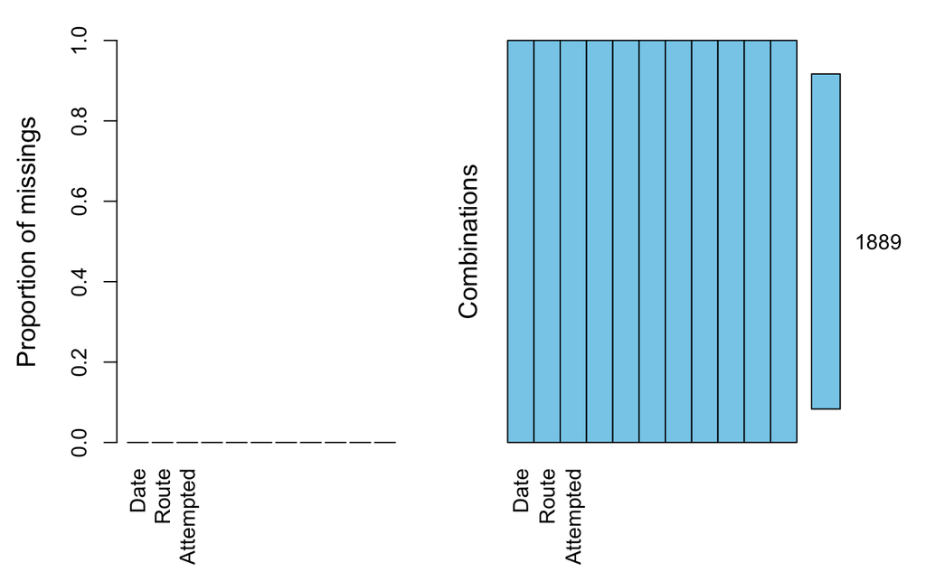

```r
# Using VIM library
vim_plot <- aggr(df, numbers=TRUE, prop = c(TRUE, FALSE))
```

This function plots and calculates the amount of missing values in each variable and in certain combinations. On the right-hand chart, we can see the missing values’ distribution in a combination. Notice that left-hand chart uses proportions as Y-axis, while the right one uses real number because we set prop = c(TRUE, FALSE).

```
 /\     /\
{  `---'  }
{  O   O  }
==>  V <==  No need for mice. This data set is completely observed.
 \  \|/  /
  `-----'

     Date Route Attempted Succeeded Success.Percentage Battery.Voltage.AVG Temperature.AVG
1889    1     1         1         1                  1                   1               1
        0     0         0         0                  0                   0               0
     Relative.Humidity.AVG Wind.Speed.Daily.AVG Wind.Direction.AVG Solare.Radiation.AVG
1889                     1                    1                  1                    1 0
                         0                    0                  0                    0 0
```

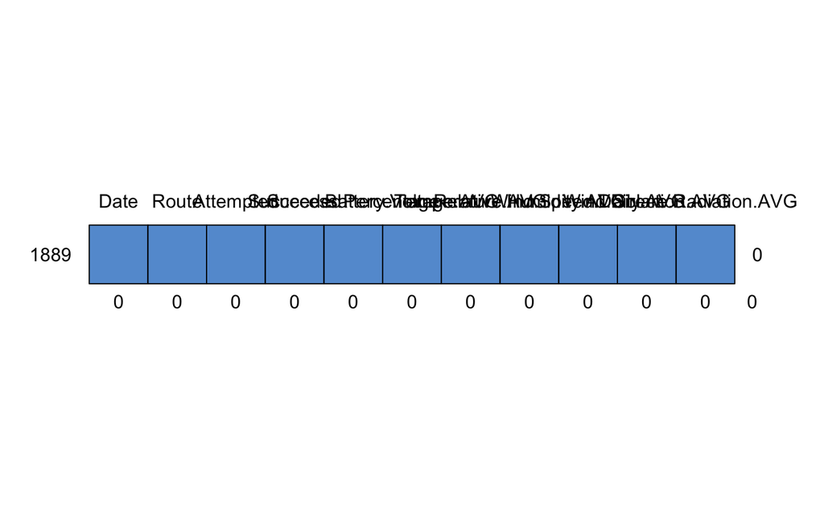

```r
# Using mice library
md.pattern(df)
```

This chart demonstrates the distribution of missing values. The values on the left side represent different groups of the data set. The values on the right side represent the total number of variables that contain missing value. The top line are names of different variables. The bottom line represents the number of missing values of each variable.

```r
# Overview of new data set
sum(is.na(df))
```

```
[1] 0
```

```r
head(df, 10)
```

|  | Date | Route | Attempted | Succeeded | Success.Percentage | Battery.Voltage.AVG | Temperature.AVG | Relative.Humidity.AVG | Wind.Speed.Daily.AVG | Wind.Direction.AVG | Solare.Radiation.AVG |
| --- | --- | --- | --- | --- | --- | --- | --- | --- | --- | --- | --- |
| 1 | 11/27/2015 | Disappointment Cleaver | 2 | 0 | 0 | 13.64375 | 26.32167 | 19.71500 | 27.839583 | 68.00417 | 88.49625 |
| 2 | 11/21/2015 | Disappointment Cleaver | 3 | 0 | 0 | 13.74958 | 31.30000 | 21.69071 | 2.245833 | 117.54967 | 93.66042 |
| 3 | 10/15/2015 | Disappointment Cleaver | 2 | 0 | 0 | 13.46125 | 46.44792 | 27.21125 | 17.163625 | 259.12138 | 138.38700 |
| 4 | 10/13/2015 | Little Tahoma | 8 | 0 | 0 | 13.53208 | 40.97958 | 28.33571 | 19.591167 | 279.77917 | 176.38267 |
| 5 | 10/9/2015 | Disappointment Cleaver | 2 | 0 | 0 | 13.21625 | 38.26042 | 74.32917 | 65.138333 | 264.68750 | 27.79129 |
| 6 | 10/3/2015 | Disappointment Cleaver | 10 | 0 | 0 | 13.57750 | 31.82292 | 62.33708 | 13.125042 | 153.93167 | 196.37521 |
| 7 | 10/3/2015 | Disappointment Cleaver | 2 | 0 | 0 | 13.57750 | 31.82292 | 62.33708 | 13.125042 | 153.93167 | 196.37521 |
| 8 | 10/2/2015 | Kautz Glacier | 2 | 0 | 0 | 13.50500 | 36.06417 | 47.01738 | 6.445917 | 247.31833 | 176.26554 |
| 9 | 10/2/2015 | Disappointment Cleaver | 2 | 0 | 0 | 13.50500 | 36.06417 | 47.01738 | 6.445917 | 247.31833 | 176.26554 |
| 10 | 9/30/2015 | Disappointment Cleaver | 2 | 0 | 0 | 13.48333 | 38.72958 | 57.36958 | 11.300750 | 216.93417 | 202.81275 |

## 5. Data Analyze

### 5.1 Relationship between different routes and climbing.

```r
Attempted <- data.frame(matrix(ncol = 3, nrow = 0))
name <- c("Route", "Situation", "Count")
colnames(Attempted) <- name

Succeeded <- data.frame(matrix(ncol = 3, nrow = 0))
name <- c("Route", "Situation", "Count")
colnames(Succeeded) <- name

for (i in c(1:22)) {
  df.temp = df[which(df$Route == unique(df$Route)[i]), ]

  Attempted.temp = as.data.frame(sum(df.temp$Attempted))
  Attempted.temp$Route <- unique(df$Route)[i]
  Attempted.temp$Attempted <- "Attempted"
  Attempted <- rbind(Attempted, Attempted.temp)

  Succeeded.temp = as.data.frame(sum(df.temp$Succeeded))
  Succeeded.temp$Route <- unique(df$Route)[i]
  Succeeded.temp$Succeeded <- "Succeeded"
  Succeeded <- rbind(Succeeded, Succeeded.temp)
}

Attempted <- tibble::rowid_to_column(Attempted, "ID")
Succeeded <- tibble::rowid_to_column(Succeeded, "ID")
name <- c("ID", "Count", "Route", "Situation")
colnames(Attempted) <- name
colnames(Succeeded) <- name

total <- rbind(Attempted, Succeeded)
```

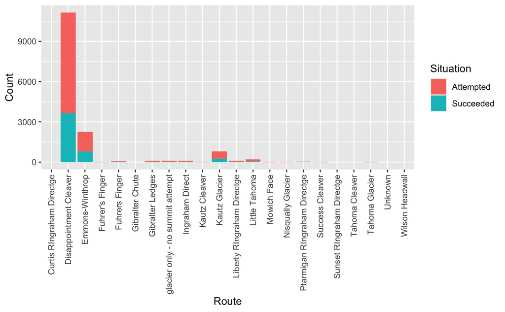

```r
ggplot(total, aes(x=Route, y=Count, fill=Situation)) + geom_bar(stat="identity",position="stack") + theme(axis.text.x=element_text(angle=90, hjust=1, vjust=.5))
```

For this diagram, we can conclude that most of the climbs were attempted through the ‘disappointment cleaver route’ and a few considerable number through the ‘Emmons’ and ‘Kaultz Galcier’.

### 5.2 Relationship between different routes and succeeded ratio

```r
Succeeded.ratio <- data.frame(matrix(ncol = 2, nrow = 0))
name <- c("Route", "Ratio")
colnames(Succeeded.ratio) <- name

for (i in c(1:22)) {
  temp = total[which(total$Route == unique(total$Route)[i]), ]
  a_t = temp[which(temp$Situation == "Attempted"), ]["Count"]
  s_t = temp[which(temp$Situation == "Succeeded"), ]["Count"]
  r_t = s_t[1] / (a_t[1] + s_t[1])

  Succeeded.temp = as.data.frame(r_t)
  Succeeded.temp$Route <- unique(total$Route)[i]
  Succeeded.ratio <- rbind(Succeeded.ratio, Succeeded.temp)
}

name <- c("Ratio", "Route")
colnames(Succeeded.ratio) <- name
```

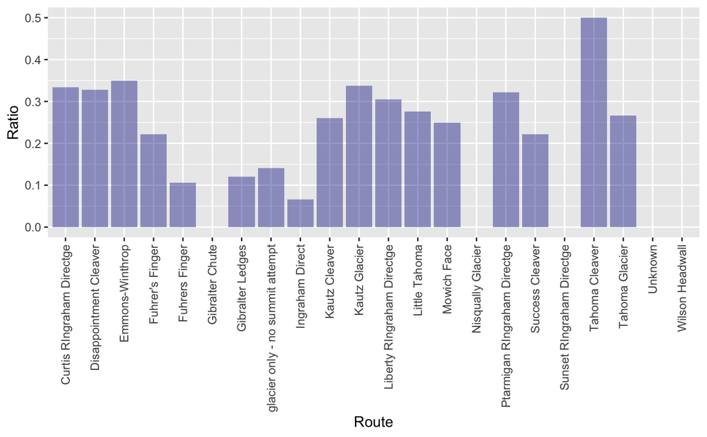

```r
ggplot(Succeeded.ratio, aes(x=Route, y=Ratio), color="darkblue") + geom_bar(stat="identity", fill="darkblue", alpha=0.4) + theme(axis.text.x=element_text(angle=90, hjust=1, vjust=.5))
```

As we can see, the most popular route doesn’t have the highest succeeded ratio. For example, the route ‘Tahoma Cleaver’ has the highest succeeded ratio although there are less people who choose this route. This is because biases can affect the true data distribution in the case of small sample sizes. Therefore, we can consider 0.32 as the average succeeded ratio.

### 5.3 Time Series Analysis

```r
data_for <- data.frame(matrix(ncol = 3, nrow = 0))
name <- c("Month", "Succeeded", "Attempted")
colnames(data_for) <- name

for (i in c(1:length(df$Date))) {
  data_formatted <- as.Date(df$Date[i], format = "%m/%d/%Y")
  class(data_formatted)
  x_month <- format(data_formatted, "%m")

  data_for.temp = as.data.frame(x_month)
  data_for.temp$Succeeded <- df$Succeeded[i]
  data_for.temp$Attempted <- df$Attempted[i]

  data_for <- rbind(data_for, data_for.temp)
}

final <- data.frame(matrix(ncol = 3, nrow = 0))

date_set <- c("01", "02", "03", "04", "05", "06", "07", "08", "09", "10", "11", "12")
for (i in date_set) {

  df_for_count = data_for[which(data_for$x_month == i), ]

  final.temp = as.data.frame(i)
  final.temp$Situation <- "Succeeded"
  final.temp$Count <- sum(df_for_count$Succeeded)

  final.temp2 = as.data.frame(i)
  final.temp2$Situation <- "Attempted"
  final.temp2$Count <- sum(df_for_count$Attempted)

  final <- rbind(final, final.temp)
  final <- rbind(final, final.temp2)
}

name <- c("Month", "Situation", "Count")
colnames(final) <- name

final$Month[final$Month == "01"] = "January"
final$Month[final$Month == "02"] = "February"
final$Month[final$Month == "03"] = "March"
final$Month[final$Month == "04"] = "April"
final$Month[final$Month == "05"] = "May"
final$Month[final$Month == "06"] = "June"
final$Month[final$Month == "07"] = "July"
final$Month[final$Month == "08"] = "August"
final$Month[final$Month == "09"] = "September"
final$Month[final$Month == "10"] = "October"
final$Month[final$Month == "11"] = "November"
final$Month[final$Month == "12"] = "December"
```

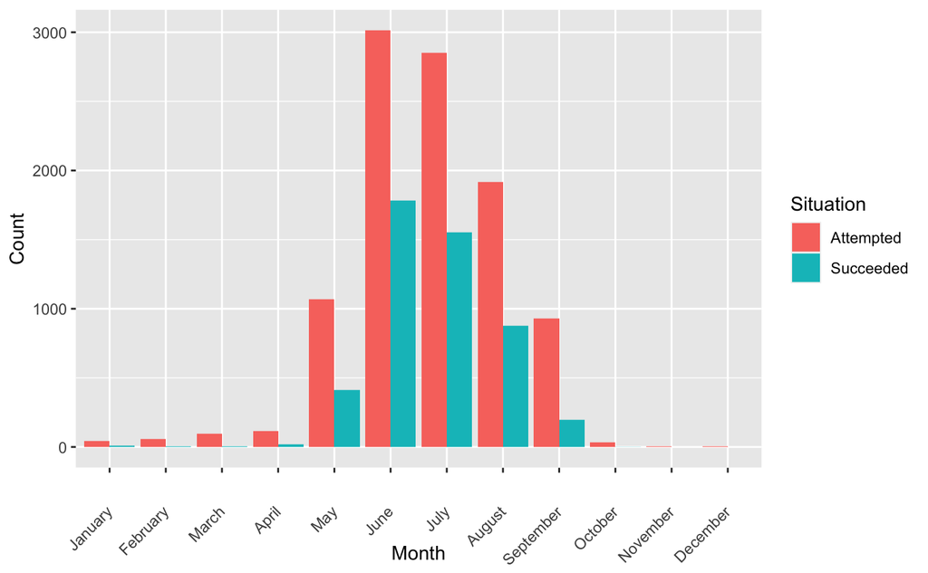

```r
ggplot(data=final, mapping=aes(x=Month, y=Count, fill=Situation)) + geom_bar(stat='identity', position='dodge') + theme(axis.text.x=element_text(angle=45, hjust=1, vjust=.5)) +   scale_x_discrete(limits=c("January", "February", "March", "April", "May", "June", "July", "August", "September", "October", "November", "December"))
```

This diagram reflects temporal features of our data set. Most number of the climbing attempts and the successes are during the months, ‘May’, ‘June’, ‘July’, ‘August’ and ‘September’.

## 6. Feature Selection

```r
cormat <- round(cor(select(df, c("Success.Percentage", "Battery.Voltage.AVG", "Temperature.AVG", "Relative.Humidity.AVG", "Wind.Speed.Daily.AVG", "Wind.Direction.AVG", "Solare.Radiation.AVG"))), 2)
# Merge data
melted_cormat = melt(cormat)
```

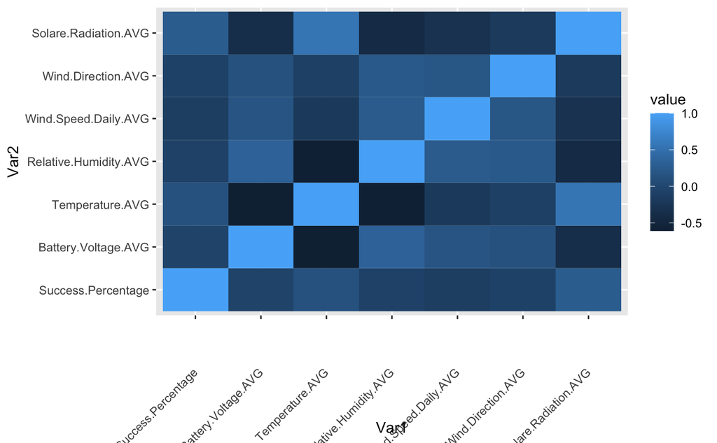

```r
ggplot(data=melted_cormat, aes(x=Var1, y=Var2, fill=value)) + geom_tile() + theme(axis.text.x=element_text(angle=45, hjust=1, vjust=.5))
```

1. From this diagram, we find that average temperature and average battery voltage have strong correlations. But both of them don’t contribute much to our dependent variable (submit ratio).
2. Average solar radiation and average temperature both are correlated to average relative humidity, average daily wind speed and average daily wind direction.
3. Drop average solar radiation column because it has similar effect to our prediction target as the average temperature.
4. We also Drop average daily wind direction column and use average daily wind speed instead. Because average daily wind speed has a stronger correlation to the prediction target.
5. As wind speed has increased, the temperature has decrease. Therefore, during colder days, the wind speed is high which has negative effect on climbing.

#### Finally, we choose 4 columns to feed into the linear regression model, which are average temperature, average relative humidity, average daily wind speed, routes. The prediction target is succeeded ratio.

## 7. Data Encoding

```r
# Route column contains categorical values. We use One-hot encoding to encode char values into numeric values.
df <- tibble::rowid_to_column(df, "ID")
df.new = model.matrix(~Route, df) %>% as.data.frame()
df.new <- tibble::rowid_to_column(df.new, "ID")
df.new.total <- merge(df, df.new, by="ID")

df.new.total <- subset(df.new.total, select=-c(ID, Date, Attempted, Succeeded, Battery.Voltage.AVG, Wind.Direction.AVG, Solare.Radiation.AVG, Route,`(Intercept)`))
```

```r
# Check for NAs
sum(is.na(df.new.total))
```

```
[1] 0
```

## 8. Data Normalization

```r
# Normalization
min_max_norm <- function(x) {
      (x - min(x)) / (max(x) - min(x))
}
df.new.total.norm <- as.data.frame(lapply(df.new.total, min_max_norm))
```

#### Notice that we use Min-Max normalization instead of Standardization for data rescaling for two reasons.First, we want to bound the data between 0 and 1. Also, all weather data doesn’t follow Gaussian Distribution. Their distributions are unkown to us.

```r
# Standardization
# df.new.total.norm1 = sapply(df.new.total1, function(df.new.total1) (df.new.total1-mean(df.new.total1))/sd(df.new.total1))
```

```r
summary(df.new.total.norm)
```

```
 Success.Percentage Temperature.AVG  Relative.Humidity.AVG Wind.Speed.Daily.AVG
 Min.   :0.0000     Min.   :0.0000   Min.   :0.0000        Min.   :0.00000
 1st Qu.:0.0000     1st Qu.:0.5382   1st Qu.:0.2019        1st Qu.:0.06771
 Median :0.4167     Median :0.6735   Median :0.3854        Median :0.11168
 Mean   :0.4504     Mean   :0.6869   Mean   :0.4052        Mean   :0.16102
 3rd Qu.:1.0000     3rd Qu.:0.8474   3rd Qu.:0.6026        3rd Qu.:0.22503
 Max.   :1.0000     Max.   :1.0000   Max.   :1.0000        Max.   :1.00000
 RouteDisappointment.Cleaver RouteEmmons.Winthrop RouteFuhrer.s.Finger RouteFuhrers.Finger
 Min.   :0.0000              Min.   :0.0000       Min.   :0.000000     Min.   :0.00000
 1st Qu.:0.0000              1st Qu.:0.0000       1st Qu.:0.000000     1st Qu.:0.00000
 Median :1.0000              Median :0.0000       Median :0.000000     Median :0.00000
 Mean   :0.6824              Mean   :0.1556       Mean   :0.002647     Mean   :0.01429
 3rd Qu.:1.0000              3rd Qu.:0.0000       3rd Qu.:0.000000     3rd Qu.:0.00000
 Max.   :1.0000              Max.   :1.0000       Max.   :1.000000     Max.   :1.00000
 RouteGibralter.Chute RouteGibralter.Ledges Routeglacier.only...no.summit.attempt
 Min.   :0.0000000    Min.   :0.00000       Min.   :0.00000
 1st Qu.:0.0000000    1st Qu.:0.00000       1st Qu.:0.00000
 Median :0.0000000    Median :0.00000       Median :0.00000
 Mean   :0.0005294    Mean   :0.01535       Mean   :0.01323
 3rd Qu.:0.0000000    3rd Qu.:0.00000       3rd Qu.:0.00000
 Max.   :1.0000000    Max.   :1.00000       Max.   :1.00000
 RouteIngraham.Direct RouteKautz.Cleaver RouteKautz.Glacier RouteLiberty.RIngraham.Directge
 Min.   :0.00000      Min.   :0.000000   Min.   :0.00000    Min.   :0.00000
 1st Qu.:0.00000      1st Qu.:0.000000   1st Qu.:0.00000    1st Qu.:0.00000
 Median :0.00000      Median :0.000000   Median :0.00000    Median :0.00000
 Mean   :0.01271      Mean   :0.003706   Mean   :0.05135    Mean   :0.01535
 3rd Qu.:0.00000      3rd Qu.:0.000000   3rd Qu.:0.00000    3rd Qu.:0.00000
 Max.   :1.00000      Max.   :1.000000   Max.   :1.00000    Max.   :1.00000
 RouteLittle.Tahoma RouteMowich.Face   RouteNisqually.Glacier RoutePtarmigan.RIngraham.Directge
 Min.   :0.00000    Min.   :0.000000   Min.   :0.000000       Min.   :0.000000
 1st Qu.:0.00000    1st Qu.:0.000000   1st Qu.:0.000000       1st Qu.:0.000000
 Median :0.00000    Median :0.000000   Median :0.000000       Median :0.000000
 Mean   :0.01906    Mean   :0.001588   Mean   :0.001059       Mean   :0.004235
 3rd Qu.:0.00000    3rd Qu.:0.000000   3rd Qu.:0.000000       3rd Qu.:0.000000
 Max.   :1.00000    Max.   :1.000000   Max.   :1.000000       Max.   :1.000000
 RouteSuccess.Cleaver RouteSunset.RIngraham.Directge RouteTahoma.Cleaver RouteTahoma.Glacier
 Min.   :0.000000     Min.   :0.0000000              Min.   :0.0000000   Min.   :0.000000
 1st Qu.:0.000000     1st Qu.:0.0000000              1st Qu.:0.0000000   1st Qu.:0.000000
 Median :0.000000     Median :0.0000000              Median :0.0000000   Median :0.000000
 Mean   :0.001059     Mean   :0.0005294              Mean   :0.0005294   Mean   :0.002118
 3rd Qu.:0.000000     3rd Qu.:0.0000000              3rd Qu.:0.0000000   3rd Qu.:0.000000
 Max.   :1.000000     Max.   :1.0000000              Max.   :1.0000000   Max.   :1.000000
  RouteUnknown       RouteWilson.Headwall
 Min.   :0.0000000   Min.   :0.000000
 1st Qu.:0.0000000   1st Qu.:0.000000
 Median :0.0000000   Median :0.000000
 Mean   :0.0005294   Mean   :0.001059
 3rd Qu.:0.0000000   3rd Qu.:0.000000
 Max.   :1.0000000   Max.   :1.000000
```

## 9. Data Set Partitioning

We use 80% of the data set for training, and the rest for testing.

```r
# Random sample for data set division
# X <- subset(df.new.total.norm, select=-Success.Percentage)
# Y <- subset(df.new.total.norm, select=Success.Percentage)

## 80% of the sample size
smp_size <- floor(0.80 * nrow(df.new.total.norm))

## Set the seed to make your partition reproducible
set.seed(123)
# train_ind <- sample(seq_len(nrow(X)), size = smp_size)
# train_X <- X[train_ind, ]
# test_X <- X[-train_ind, ]
# train_Y <- Y[train_ind, ]
# test_Y <- Y[-train_ind, ]

train_ind <- sample(seq_len(nrow(df.new.total.norm)), size = smp_size)

train <- df.new.total.norm[train_ind, ]
test <- df.new.total.norm[-train_ind, ]
```

## 10. Linear Regression

```r
# Feed training data in to the multiple linear regression model
regressor1 = lm(formula = Success.Percentage ~ ., data = train)
regressor2 = lm(formula = Success.Percentage ~ -Wind.Speed.Daily.AVG, data = train)
regressor3 = lm(formula = Success.Percentage ~ -Temperature.AVG, data = train)
regressor4 = lm(formula = Success.Percentage ~ -Relative.Humidity.AVG, data = train)

summary(regressor1)
```

```
Call:
lm(formula = Success.Percentage ~ ., data = train)

Residuals:
     Min       1Q   Median       3Q      Max
-0.64849 -0.46194 -0.02264  0.48015  1.00431

Coefficients: (1 not defined because of singularities)
                                      Estimate Std. Error t value Pr(>|t|)
(Intercept)                            0.53332    0.32349   1.649   0.0994 .
Temperature.AVG                        0.14675    0.08702   1.686   0.0919 .
Relative.Humidity.AVG                 -0.04257    0.06077  -0.701   0.4837
Wind.Speed.Daily.AVG                  -0.37209    0.08495  -4.380 1.27e-05 ***
RouteDisappointment.Cleaver           -0.09404    0.31569  -0.298   0.7658
RouteEmmons.Winthrop                  -0.07769    0.31678  -0.245   0.8063
RouteFuhrer.s.Finger                  -0.49214    0.38654  -1.273   0.2031
RouteFuhrers.Finger                   -0.45654    0.32771  -1.393   0.1638
RouteGibralter.Chute                  -0.25732    0.54755  -0.470   0.6385
RouteGibralter.Ledges                 -0.42287    0.32882  -1.286   0.1986
Routeglacier.only...no.summit.attempt -0.44962    0.33339  -1.349   0.1777
RouteIngraham.Direct                  -0.36871    0.33156  -1.112   0.2663
RouteKautz.Cleaver                    -0.38414    0.37336  -1.029   0.3037
RouteKautz.Glacier                    -0.10235    0.31961  -0.320   0.7488
RouteLiberty.RIngraham.Directge       -0.08793    0.32782  -0.268   0.7886
RouteLittle.Tahoma                    -0.12099    0.32645  -0.371   0.7110
RouteMowich.Face                      -0.05618    0.44585  -0.126   0.8997
RouteNisqually.Glacier                -0.40315    0.54624  -0.738   0.4606
RoutePtarmigan.RIngraham.Directge      0.11987    0.36397   0.329   0.7420
RouteSuccess.Cleaver                  -0.08323    0.44605  -0.187   0.8520
RouteSunset.RIngraham.Directge              NA         NA      NA       NA
RouteTahoma.Cleaver                    0.42361    0.54601   0.776   0.4380
RouteTahoma.Glacier                   -0.14799    0.38650  -0.383   0.7018
RouteUnknown                          -0.43285    0.54744  -0.791   0.4293
RouteWilson.Headwall                  -0.53927    0.44643  -1.208   0.2272
---
Signif. codes:  0 ‘***’ 0.001 ‘**’ 0.01 ‘*’ 0.05 ‘.’ 0.1 ‘ ’ 1

Residual standard error: 0.4455 on 1487 degrees of freedom
Multiple R-squared:  0.06638,   Adjusted R-squared:  0.05194
F-statistic: 4.597 on 23 and 1487 DF,  p-value: 4.509e-12
```

```r
# Test the trained model
y_pred1 = predict(regressor1, newdata = test)
y_pred2 = predict(regressor2, newdata = test)
y_pred3 = predict(regressor3, newdata = test)
y_pred4 = predict(regressor4, newdata = test)
```

## 11. Evaluation

```r
# summary(y_pred)
# summary(test1$Success.Percentage)

# round(RMSE(y_pred, test1$Success.Percentage), 3) # Root mean squared error
# round(MAE(y_pred, test1$Success.Percentage), 3) # Mean Absolute Error

cat("Experiment 1 - \n")
```

```
Experiment 1 -
```

```r
cat("RMSE for feature set 1: ", round(RMSE(y_pred1, test$Success.Percentage), 3), "\n")
```

```
RMSE for feature set 1:  0.456
```

```r
cat("MAE for feature set 1: ", round(MAE(y_pred1, test$Success.Percentage), 3), "\n")
```

```
MAE for feature set 1:  0.425
```

```r
cat("\nExperiment 2 - \n")
```

```
Experiment 2 -
```

```r
cat("RMSE for feature set 2: ", round(RMSE(y_pred2, test$Success.Percentage), 3), "\n")
```

```
RMSE for feature set 2:  0.459
```

```r
cat("MAE for feature set 2: ", round(MAE(y_pred2, test$Success.Percentage), 3), "\n")
```

```
MAE for feature set 2:  0.441
```

```r
cat("\nExperiment 3 - \n")
```

```
Experiment 3 -
```

```r
cat("RMSE for feature set 3: ", round(RMSE(y_pred3, test$Success.Percentage), 3), "\n")
```

```
RMSE for feature set 3:  0.459
```

```r
cat("MAE for feature set 3: ", round(MAE(y_pred3, test$Success.Percentage), 3), "\n")
```

```
MAE for feature set 3:  0.441
```

```r
cat("\nExperiment 4 - \n")
```

```
Experiment 4 -
```

```r
cat("RMSE for feature set 4: ", round(RMSE(y_pred4, test$Success.Percentage), 3), "\n")
```

```
RMSE for feature set 4:  0.459
```

```r
cat("MAE for feature set 4: ", round(MAE(y_pred4, test$Success.Percentage), 3), "\n")
```

```
MAE for feature set 4:  0.441
```

```r
cat("Last Block!")
```